# Linear Model

Szymon Kubica

# Installing and importing packages

```r
#install.packages("readxl")
#install.packages("tidyverse")

library(readxl)
library(tidyverse)
library(caret)
```

# Loading and cleaning data

## Loading Data

I’ve got this data from stat.gov.pl this data is about life duration in cities and villages in Poland between 1990 and 2022.

```r
rawData<- read_excel("dane.xlsx")
```

```r
rawData
```

| Przeciętne trwanie życia noworodka (miasta/wieś) w latach 1990-2022 a) | ...2 | ...3 | ...4 | ...5 | ...6 | ...7 | ...8 |
| --- | --- | --- | --- | --- | --- | --- | --- |
| NA | NA | NA | NA | NA | NA | NA | NA |
| Rok | Ogółem | NA | Miasta | NA | Wieś | NA | NA |
| NA | mężczyźni | kobiety | mężczyźni | kobiety | mężczyźni | kobiety | NA |
| 1990 | 66.2 | 75.2 | 66.2 | 74.900000000000006 | 66.2 | 75.8 | NA |
| 1991 | 65.900000000000006 | 75.099999999999994 | 65.8 | 74.7 | 66 | 75.7 | NA |
| 1992 | 66.5 | 75.5 | 66.3 | 75.099999999999994 | 66.599999999999994 | 76 | NA |
| 1993 | 67.2 | 75.8 | 67.099999999999994 | 75.5 | 67.2 | 76.3 | NA |
| 1994 | 67.5 | 76.099999999999994 | 67.599999999999994 | 75.7 | 67.2 | 76.599999999999994 | NA |
| 1995 | 67.599999999999994 | 76.400000000000006 | 67.8 | 76.099999999999994 | 67.3 | 76.8 | NA |
| 1996 | 68.099999999999994 | 76.599999999999994 | 68.400000000000006 | 76.400000000000006 | 67.8 | 76.900000000000006 | NA |

[output cut: 29 more lines]

## Cleaning data

Deleting first 3 rows and last 3

```r
cleaningData<- rawData
cleaningData<- cleaningData%>% slice(-1:-3,-37:-39)
```

For renaming columns

```r
col1<- colnames(cleaningData)[1]
col2<- colnames(cleaningData)[2]
col3<- colnames(cleaningData)[3]
col4<- colnames(cleaningData)[4]
col5<- colnames(cleaningData)[5]
col6<- colnames(cleaningData)[6]
col7<- colnames(cleaningData)[7]
col8<- colnames(cleaningData)[8]
```

Renaming

```r
cleaningData<- cleaningData%>%rename(year=col1,summaryMen=col2,summaryWomen=col3,
                                     cityMen=col4,cityWomen=col5, villageMen=col6,villageWomen=col7)
```

Deleting null column

```r
cleaningData=cleaningData[,-which(names(cleaningData)==col8)]
```

```r
head(cleaningData)
```

| year | summaryMen | summaryWomen | cityMen | cityWomen | villageMen | villageWomen |
| --- | --- | --- | --- | --- | --- | --- |
| 1990 | 66.2 | 75.2 | 66.2 | 74.900000000000006 | 66.2 | 75.8 |
| 1991 | 65.900000000000006 | 75.099999999999994 | 65.8 | 74.7 | 66 | 75.7 |
| 1992 | 66.5 | 75.5 | 66.3 | 75.099999999999994 | 66.599999999999994 | 76 |
| 1993 | 67.2 | 75.8 | 67.099999999999994 | 75.5 | 67.2 | 76.3 |
| 1994 | 67.5 | 76.099999999999994 | 67.599999999999994 | 75.7 | 67.2 | 76.599999999999994 |
| 1995 | 67.599999999999994 | 76.400000000000006 | 67.8 | 76.099999999999994 | 67.3 | 76.8 |

Changing data type from character to double

```r
cleaningData<- cleaningData %>% mutate_if(is.character,as.double)
```

```r
cleanData<- cleaningData
```

```r
head(cleanData)
```

| year | summaryMen | summaryWomen | cityMen | cityWomen | villageMen | villageWomen |
| --- | --- | --- | --- | --- | --- | --- |
| 1990 | 66.2 | 75.2 | 66.2 | 74.9 | 66.2 | 75.8 |
| 1991 | 65.9 | 75.1 | 65.8 | 74.7 | 66.0 | 75.7 |
| 1992 | 66.5 | 75.5 | 66.3 | 75.1 | 66.6 | 76.0 |
| 1993 | 67.2 | 75.8 | 67.1 | 75.5 | 67.2 | 76.3 |
| 1994 | 67.5 | 76.1 | 67.6 | 75.7 | 67.2 | 76.6 |
| 1995 | 67.6 | 76.4 | 67.8 | 76.1 | 67.3 | 76.8 |

Now our data is clean and ready

# Linear Model

## Spiting data into train and test sets

```r
dataTrainSize<- floor(length(cleanData$year)*0.8)
dataTrainSize
```

```
[1] 26
```

Because our data is time series, we’ll take first 26 records as our train set. We are going to test our linear model with all remaining records.

```r
trainData<-cleanData[1:dataTrainSize,]
testData<-cleanData[(dataTrainSize+1):length(cleanData$year),]
```

## Linear Model

### Summary women

```r
linearModelWomen<- lm(summaryWomen ~ year, data = trainData)
linearModelSummaryWomen<- summary(linearModelWomen)
linearModelSummaryWomen
```

```
Call:
lm(formula = summaryWomen ~ year, data = trainData)

Residuals:
     Min       1Q   Median       3Q      Max
-0.31197 -0.12691 -0.02952  0.12048  0.42048

Coefficients:
              Estimate Std. Error t value Pr(>|t|)
(Intercept) -4.656e+02  1.008e+01  -46.18   <2e-16 ***
year         2.717e-01  5.035e-03   53.97   <2e-16 ***
---
Signif. codes:  0 ‘***’ 0.001 ‘**’ 0.01 ‘*’ 0.05 ‘.’ 0.1 ‘ ’ 1

Residual standard error: 0.1925 on 24 degrees of freedom
Multiple R-squared:  0.9918,    Adjusted R-squared:  0.9915
F-statistic:  2913 on 1 and 24 DF,  p-value: < 2.2e-16
```

### Graph

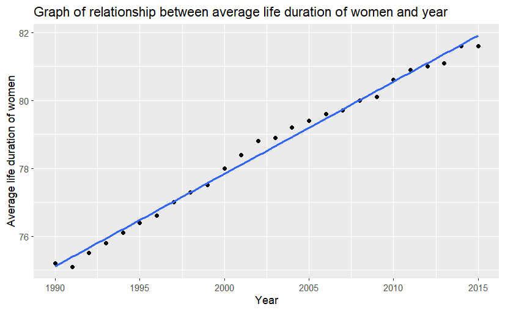

```r
ggplot(trainData, aes(x=year, y=summaryWomen)) + labs(title="Graph of relationship between average life duration of women and year", x='Year', y = "Average life duration of women")+ geom_point() + geom_smooth(method='lm' ,formula=y~x, se=FALSE)
```

### Village men

```r
linearModelMenVillage<- lm(villageMen ~ year, data = trainData)
linearModelSummaryMen<- summary(linearModelMenVillage)
linearModelSummaryMen
```

```
Call:
lm(formula = villageMen ~ year, data = trainData)

Residuals:
     Min       1Q   Median       3Q      Max
-0.46321 -0.23464 -0.03198  0.16004  0.71918

Coefficients:
              Estimate Std. Error t value Pr(>|t|)
(Intercept) -4.746e+02  1.647e+01  -28.81   <2e-16 ***
year         2.718e-01  8.226e-03   33.04   <2e-16 ***
---
Signif. codes:  0 ‘***’ 0.001 ‘**’ 0.01 ‘*’ 0.05 ‘.’ 0.1 ‘ ’ 1

Residual standard error: 0.3146 on 24 degrees of freedom
Multiple R-squared:  0.9785,    Adjusted R-squared:  0.9776
F-statistic:  1091 on 1 and 24 DF,  p-value: < 2.2e-16
```

### Graph

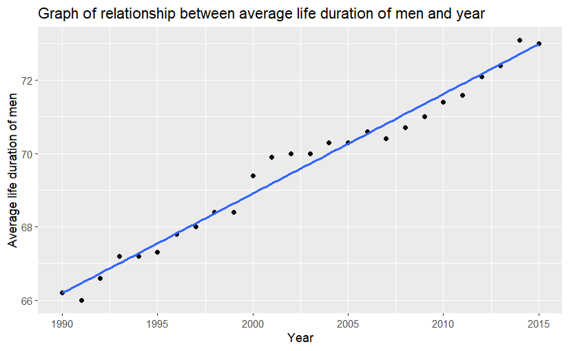

```r
ggplot(trainData, aes(x=year, y=villageMen)) + labs(title="Graph of relationship between average life duration of men and year", x='Year', y = "Average life duration of men") + geom_point() + geom_smooth(method='lm' ,formula=y~x, se=FALSE)
```

In both cases line looks well fitted for our point’s. Residual standard error looks small and R-squared is close to 1 and that means our model is well fitted for our data.

## Assumptions

Before we draw conclusion, we have to answer one question. Is our model valid?

### Normal distribution residuals

Our sample is small enough to use Shaprio- Wilk test

```r
shapiro.test(linearModelWomen$residuals)
```

```
    Shapiro-Wilk normality test

data:  linearModelWomen$residuals
W = 0.97473, p-value = 0.7471
```

```r
shapiro.test(linearModelMenVillage$residuals)
```

```
    Shapiro-Wilk normality test

data:  linearModelMenVillage$residuals
W = 0.95429, p-value = 0.2915
```

Our p-value is much greater than 0.05. That means we can’t reject alternative hypothesis.

We can check Q-Q plot to be sure about residuals distribution.

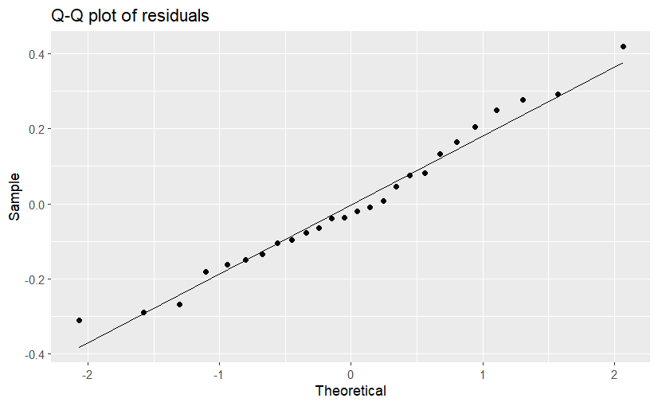

```r
ggplot(linearModelWomen, aes(sample=.resid)) + geom_qq() + geom_qq_line() + labs(title='Q-Q plot of residuals', x='Theoretical', y='Sample')
```

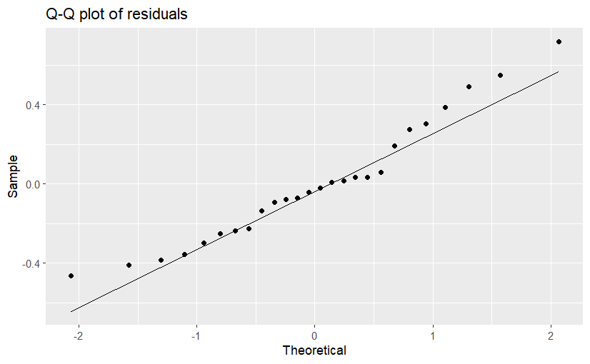

```r
ggplot(linearModelMenVillage, aes(sample=.resid)) + geom_qq() + geom_qq_line() + labs(title='Q-Q plot of residuals', x='Theoretical', y='Sample')
```

We can adopt residuals distribution is normal.

### Mean residuals close to 0

```r
t.test(linearModelWomen$residuals)
```

```
    One Sample t-test

data:  linearModelWomen$residuals
t = 2.0389e-16, df = 25, p-value = 1
alternative hypothesis: true mean is not equal to 0
95 percent confidence interval:
 -0.07619808  0.07619808
sample estimates:
   mean of x
7.543545e-18
```

```r
t.test(linearModelMenVillage$residuals)
```

```
    One Sample t-test

data:  linearModelMenVillage$residuals
t = -7.0543e-17, df = 25, p-value = 1
alternative hypothesis: true mean is not equal to 0
95 percent confidence interval:
 -0.1244997  0.1244997
sample estimates:
    mean of x
-4.264322e-18
```

T- test showed that residuals mean is almost equals 0.

### Independent residuals

```r
lmtest::dwtest(linearModelWomen)
```

```
    Durbin-Watson test

data:  linearModelWomen
DW = 0.6831, p-value = 1.569e-05
alternative hypothesis: true autocorrelation is greater than 0
```

```r
lmtest::dwtest(linearModelMenVillage)
```

```
    Durbin-Watson test

data:  linearModelMenVillage
DW = 0.87165, p-value = 0.0002814
alternative hypothesis: true autocorrelation is greater than 0
```

p-value is less than 0.05. That means that residuals are not independent.

### Homoscedasticity

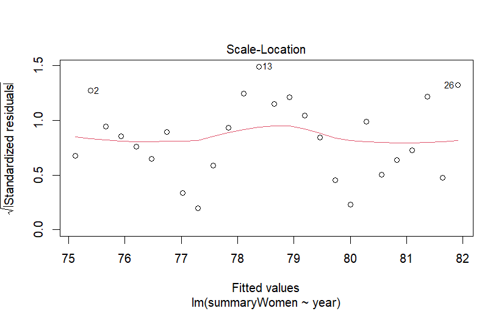

```r
plot(linearModelWomen, which = 3)
```

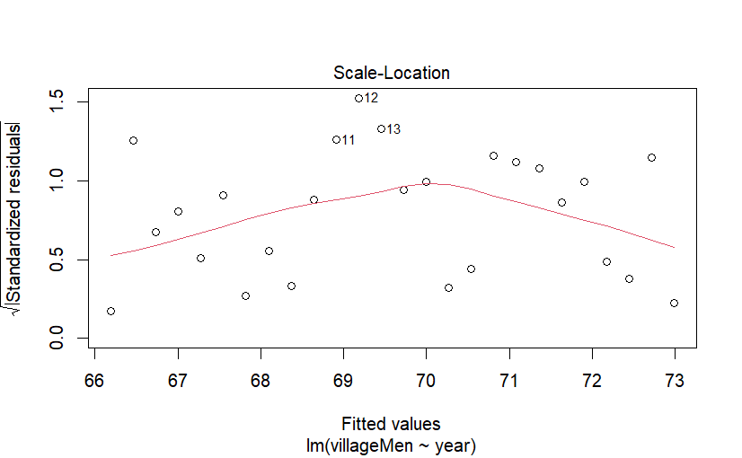

```r
plot(linearModelMenVillage, which = 3)
```

```r
lmtest::bptest(linearModelWomen)
```

```
    studentized Breusch-Pagan test

data:  linearModelWomen
BP = 0.13876, df = 1, p-value = 0.7095
```

```r
lmtest::bptest(linearModelMenVillage)
```

```
    studentized Breusch-Pagan test

data:  linearModelMenVillage
BP = 0.0016962, df = 1, p-value = 0.9671
```

p-value is much greater than 0.05 that means we can not adopt hypothesis about heteroscedasticity. That means alternative hypothesis is true.

### Summary

Our model is not fullfiling all assumptions but before we reject it, we can check model’s accuracy.

## Model accuracy

To check accuracy of a model we are going to need few functions.

```r
MAPE <- function(yActual, yPredicted){              #mean absolute percentage error
  return(mean(abs(yActual-yPredicted)/yActual)*100)
}
RMSE <- function(yActual, yPredicted){              #root mean squared error
  return(sqrt(mean((yActual-yPredicted)^2)))
}
MAE <- function(yActual, yPredicted){               #mean absolute error
  return(mean(abs(yActual-yPredicted)))
}
```

### MAPE

```r
MAPE(trainData$summaryWomen,predict(linearModelWomen, trainData))
```

```
[1] 0.191107
```

```r
MAPE(testData$summaryWomen,predict(linearModelWomen, testData))
```

```
[1] 2.174768
```

```r
MAPE(trainData$villageMen,predict(linearModelMenVillage, trainData))
```

```
[1] 0.338501
```

```r
MAPE(testData$villageMen,predict(linearModelMenVillage, testData))
```

```
[1] 1.761501
```

First number is mean absolute percentage error. It’s much greater than it was in train data. Because it’s percentage error that means, our prediction is still accurate but in far future our predictions won’t be correct.

### RMSE

```r
RMSE(trainData$summaryWomen,predict(linearModelWomen, trainData))
```

```
[1] 0.1849882
```

```r
RMSE(testData$summaryWomen,predict(linearModelWomen, testData))
```

```
[1] 2.129382
```

```r
RMSE(trainData$villageMen,predict(linearModelMenVillage, trainData))
```

```
[1] 0.3022515
```

```r
RMSE(testData$villageMen,predict(linearModelMenVillage, testData))
```

```
[1] 1.682358
```

As in the MAPE our error is greater in test set than in train set.

### MAE

```r
MAE(trainData$summaryWomen,predict(linearModelWomen, trainData))
```

```
[1] 0.1501118
```

```r
MAE(testData$summaryWomen,predict(linearModelWomen, testData))
```

```
[1] 1.756015
```

```r
MAE(trainData$villageMen,predict(linearModelMenVillage, trainData))
```

```
[1] 0.2359001
```

```r
MAE(testData$villageMen,predict(linearModelMenVillage, testData))
```

```
[1] 1.272513
```

Each error is greater in test set than in train. It’s because our data set is time series. Linear model isn’t great tool to predict changes in time because of trends. But i think it’s good enough to predict short time changes.